# Monitoramento para a qualificação da informação em saúde com foco no uso da Classificação Internacional de Doenças(CID)

7859252 - CENTRAL DE REGULACAO DE BLUMENAU E VALE DO ITAJAI

2024

[figure not shown]

A **Coordenação Municipal de Regulação**, por meio deste boletim informativo<sup>1</sup>, apresenta informações gerais sobre o panorama do uso da CID<sup>2</sup> em solicitações pendentes inseridas nos últimos 7 dias, assim como uma breve análise dos dados destas solicitações.

Conforme recomendação da auditoria multiprofissional - AUDSEMUS em Memorando No17/2024/AUDSEMUS - Relatório final de Auditoria - UNISON na Constatação 1, Constatação 2, Constatação 3, Constatação 4, Constatação 5; “Recomendação ao Gestor: A identificação oportuna e adequada da CID para a realização do Exame complementar faz parte do ato médico. Contar com a informação efetiva oferecida pela codificação CID para autorizar os exames como posteriores levantamentos estatísticos e epidemiológicos são de fundamental importância para o SUS. Recomendamos orientar os profissionais a fazer o uso adequado da ferramenta com a substituição de códigos genéricos por códigos específicos e pertinentes para cada solicitação de exames, visando sempre a qualidade de informação na Rede de Saúde.”

Considerando Ofício CMR/SEMUS 002/2024 de 3 de jun. de 2024, iniciamos o prazo de **180 dias (10/06/24 à 14/12/24)** de monitoramento semanal das solicitações inseridas no SISREG, com o objetivo de avaliar, sensibilizar e orientar todos os profissionais solicitantes (Médicos, Enfermeiros, Cirurgiões dentistas e demais profissionais de saúde que emitam solicitações inseridas no SISREG) de Unidades Solicitantes da Rede Própria, ou Contratualizada, de Atenção Primária à Saúde(APS), de Média Complexidade(MC), de Alta Complexidade(AC), e a Rede Suplementar (RS).

<sup>1</sup> Este relatório foi produzido utilizando a linguagem `Rmarkdown`.

<sup>2</sup> As informações sobre o uso da CID são baseados em conteúdo do Relatório **Resumo Fila Semanal** gerado com dados extraídos do SISREG, Sistema Nacional de Regulação disponibilizado pelo Ministério da Saúde. Para obter mais informações, acesse [este link](https://wiki.saude.gov.br/SISREG/index.php/P%C3%A1gina_principal)

Entrada semanal de solicitações em **22/11/2024** - **4.699** solicitações destas cerca de **16,77%** - **788** foram inseridas utilizando os CID’s alvos de monitoramento (R68, R688, Z00, Z000).

### 1. Ranking com o número de solicitações inseridas nos últimos 7 dias pendentes de autorização. Semana do ano: 47

| Solicitante | Quantidades | Ranking |
| --- | --- | --- |
| AMBULATORIO GERAL DA FAMILIA MARILENE GIACOMET DE AGUIAR | 58 | Posição 1 |
| AMBULATORIO GERAL DA FAMILIA MARIO JORGE VIEIRA | 58 | Posição 2 |
| ESF AFONSO BALSINI | 51 | Posição 3 |
| AMBULATORIO GERAL DA FAMILIA HAROLDO BACHMANN | 45 | Posição 4 |
| ESF GLODOALDO LINO DE AMORIM | 34 | Posição 5 |
| ESF TEREZA LESZCOWICZ | 30 | Posição 6 |
| AMBULATORIO GERAL DA FAMILIA DR DIOGO VERGARA | 28 | Posição 7 |
| ESF AUREA PFUETZENREITER | 27 | Posição 8 |
| ESF GERALDO SCHMIDT SOBRINHO II | 25 | Posição 9 |
| ESF ARMANDO ODEBRECHT | 23 | Posição 10 |
| AMBULATORIO GERAL DA FAMILIA IRMA MARTA ELISABETHA KUNZMANN | 22 | Posição 11 |
| ESF MARCO FRANCISCO BARTH | 22 | Posição 12 |
| ESF NORBERTO SPRUNG | 22 | Posição 13 |
| ESF GILSON PIVA | 21 | Posição 14 |
| ESF HAROLD EWALD | 21 | Posição 15 |
| ESF ADELINA MANOEL DA SILVA BRUECKHEIMER | 16 | Posição 16 |
| ESF PAULO PEDRO MAYERLE | 16 | Posição 17 |
| AMBULATORIO GERAL DA FAMILIA GUILHERME JENSEN | 14 | Posição 18 |
| ESF WILHELM THEODOR SCHURMANN | 14 | Posição 19 |
| ESF AUGUSTO ANTONIO SCHWEIGERT | 13 | Posição 20 |
| AMBULATORIO GERAL DA FAMILIA HEINZ SCHRADER | 12 | Posição 21 |
| ESF BENEDITO CAMARGO ROCHA | 12 | Posição 22 |
| ESF FRANZ ZIMDARS | 12 | Posição 23 |
| ESF MARTIN VOLLES I | 12 | Posição 24 |
| ESF PAULO PEDRO MAYERLE II | 12 | Posição 25 |
| ESF PEDRO KRAUSS | 12 | Posição 26 |
| ESF VALERIO JOSE STEIL | 12 | Posição 27 |
| ESF LOTHAR FRANZ | 10 | Posição 28 |
| ESF WALDEMAR FELSKI | 10 | Posição 29 |
| HOSPITAL SANTA ISABEL | 10 | Posição 30 |
| ESF JACKSON ROBERTO CARL | 9 | Posição 31 |
| ESF JOVINO INACIO CARDOSO | 7 | Posição 32 |
| ESF JOVINO INACIO CARDOSO I | 6 | Posição 33 |
| ESF GERALDO SCHMIDT SOBRINHO | 5 | Posição 34 |
| ESF HASSO ROLF MULLER | 5 | Posição 35 |
| ESF OTTO BARTSCH NETO E ODILON DE CAETANO | 5 | Posição 36 |
| ESF THAMARA KATRYNE RODRIGUES SCHMIDT | 5 | Posição 37 |
| ESF ARAO REBELO | 4 | Posição 38 |
| ESF OTTO BARTSCH NETO | 4 | Posição 39 |
| HOSPITAL SANTO ANTONIO | 4 | Posição 40 |
| CLINICA DE OLHOS SANTA ISABEL | 3 | Posição 41 |
| ESF AFONSO RABE | 3 | Posição 42 |
| ESF FREDERICO JENSEN | 3 | Posição 43 |
| ESF LEO DE CARVALHO | 3 | Posição 44 |
| ESF MARIA SCHLINDWEIN BAUMGARTNER | 3 | Posição 45 |
| ESF MARLI HELENA BATSCHAUER | 3 | Posição 46 |
| ESF WALTER REITER | 3 | Posição 47 |
| HOSPITAL UNIVERSITARIO | 3 | Posição 48 |
| POLICLINICA LINDOLF BELL | 3 | Posição 49 |
| ESF ARMANDO ODEBRECHT II | 2 | Posição 50 |
| ESF ENFERMEIRA TANIA LEITE | 2 | Posição 51 |
| ESF GLODOALDO LINO DE AMORIM II | 2 | Posição 52 |
| ESF GUSTAVO FROEHLICH BARROSO | 2 | Posição 53 |
| ESF GUSTAVO TRIBESS | 2 | Posição 54 |
| ESF MARTIN VOLLES | 2 | Posição 55 |
| ESF RUBENS BELISARIO VEDES | 2 | Posição 56 |
| ESF RUDOLFO OSWALD HESSE | 2 | Posição 57 |
| ESF SILVANA WITTE | 2 | Posição 58 |
| ESF VALERIO JOSE STEIL II | 2 | Posição 59 |
| ESF VEREADOR AUGUSTO CESAR VIANA | 2 | Posição 60 |
| CENTRO DE ESPECIALIDADES ODONTOLOGICAS I CEO I CENTRO | 1 | Posição 61 |
| CENTRO DE SAUDE DO IDOSO | 1 | Posição 62 |
| ESF ANGELO DE CAETANO | 1 | Posição 63 |
| ESF FREI JOAO MARIA BAETHGE | 1 | Posição 64 |
| ESF GERALDO SCHMIDT SOBRINHO III | 1 | Posição 65 |
| ESF GERMANO PUFF | 1 | Posição 66 |
| ESF GUSTAVO TRIBESS II | 1 | Posição 67 |
| ESF ZERBERT KRAUPP | 1 | Posição 68 |
| HOSPITAL MISERICORDIA | 1 | Posição 69 |
| SERVICO DE ATENCAO DOMICILIAR | 1 | Posição 70 |
| USB MACHADO DE ASSIS | 1 | Posição 71 |

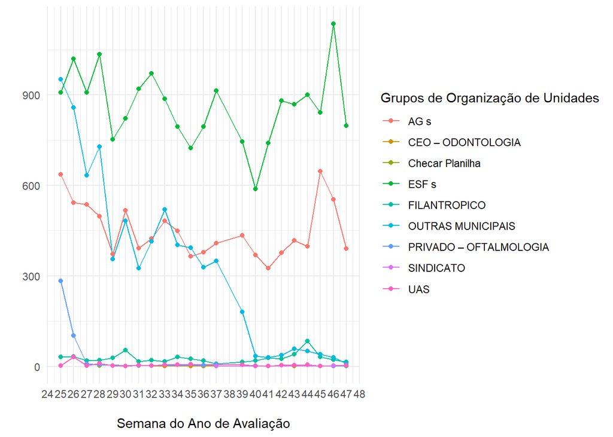

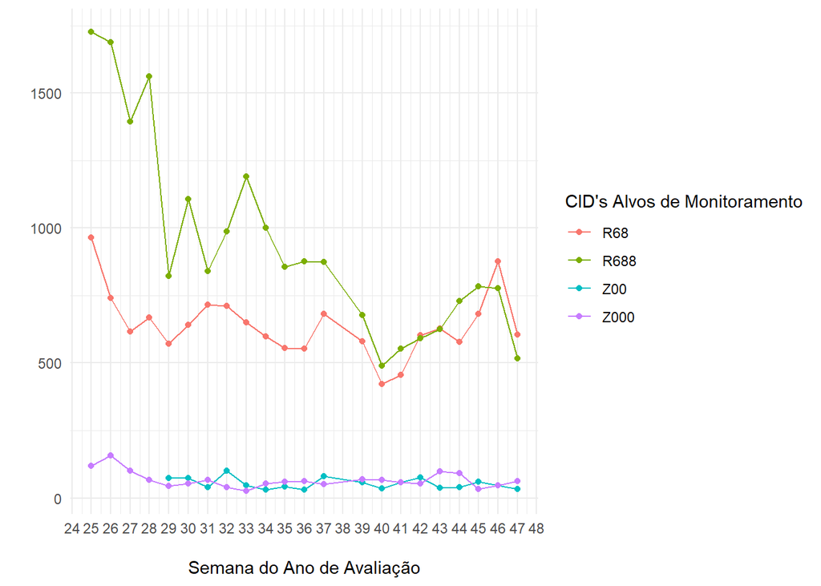

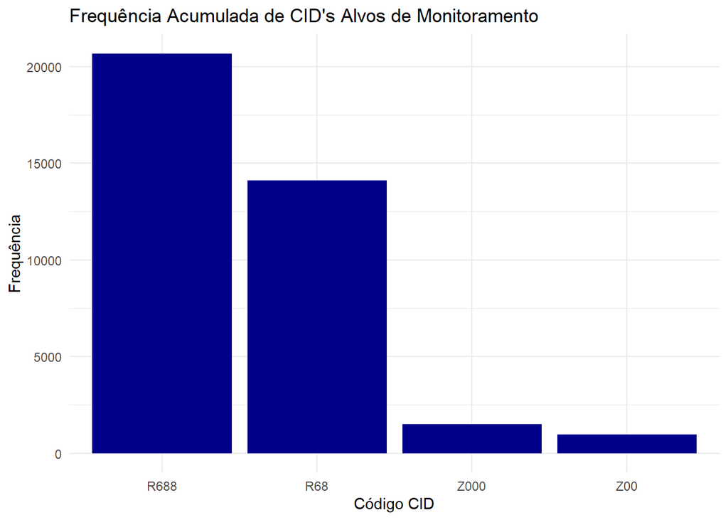